# The visual data of transportation types for commuting

*This report analyzes responses from a transport usage form to explore commuting behaviors and preferences across age and time of day.*

## Transporation usage for commuting

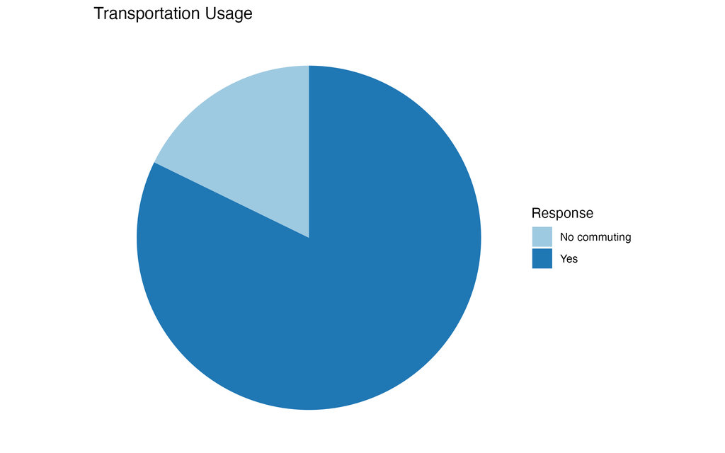

Transportaion Usage

Pie chart above displays that 82.2% of respondents use transportation for commuting, meanwhile 17.8% do not commute.

**Insight** - A significant majority (82.2%) rely on transportation for commuting, suggesting a high dependency on mobility solutions in daily life.

## Types for Transporation usage for commuting

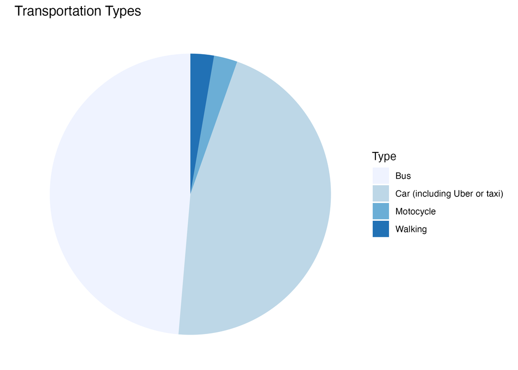

Transportation Types

Pie chart above shows that Bus and Car (including Uber/taxi) have analogous usage frequency range (48.6 ~ 45.9%), whereas usage frequency of Motorcycle and Walking are significantly lower.

**Insight** - Most number of commuters are classified analogously between Bus and Car (including Uber or taxi). This implies varied commuting preferences and potential areas for infrastructure development (e.g., improving bus services or regulating ride-share usage).

## The timestamp of responses of my survey

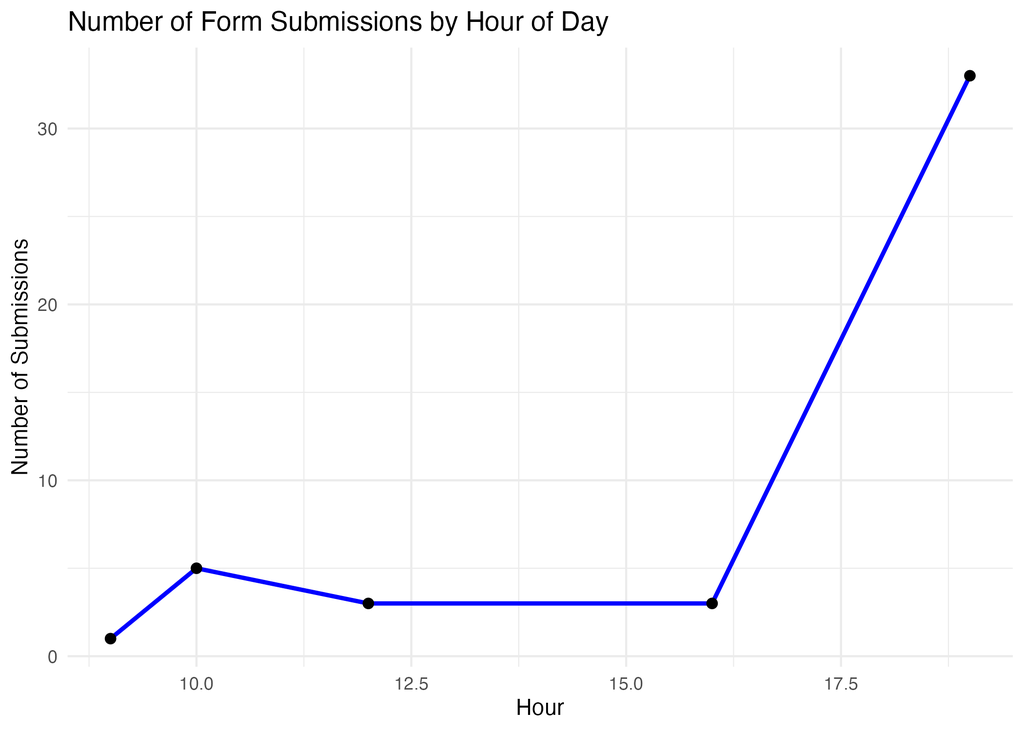

Responses timestamp

Line graph showing submission frequency by hour, peaking dramatically between 6pm and 8pm.

**Insight** - Submissions spike in the evening, which could inform future survey or outreach timings for higher engagement.

## Transporation usage for commuting by age (6am - 10pm)

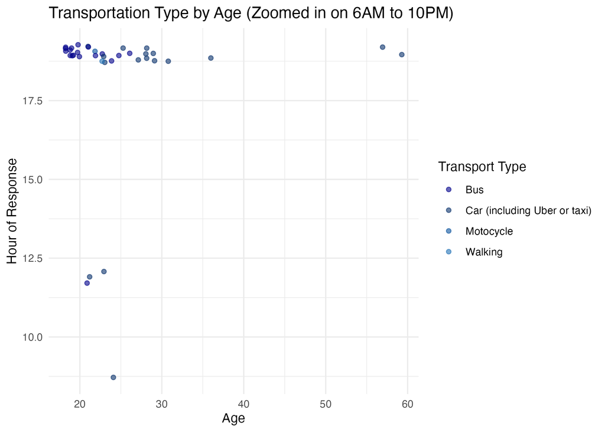

Responses timestamp

Scatter plot showing transport type distribution by age and hour of day, with most responses clustered around 6PM–8PM.

**Insight** - Younger participants (18–25) dominate the response pool. Most responses came in the evening (6PM–8PM), perhaps reflecting survey availability or user behavior patterns.

## Summary of visual data story

- Most of my respondents use transportation to commute, primarily relying on cars and buses.
- Younger people (age between 18-25) dominate the data, with most responses submitted in the evening.
- Pie and scatter plots were used to communicate the relationship between transport type for commuting and age of respondents a fixed range of timestamps.
- Data was organised using `na.rm = TRUE` in order to minimise the outlier and unsuitable values for my purpose and manipulated using `mutate()`, `group_by()` and `summarise()` to prepare plots.

This visual story informs policy makers, urban planners, and transportation services to better understand commuter trends and optimize resource planning.